# homework #6

Maryam NouriAiin

2024-03-26

Think about an ongoing study in your lab (or a paper you have read in a different class), and decide on a pattern that you might expect in your experiment if a specific hypothesis were true.

To start simply, assume that the data in each of your treatment groups follow a normal distribution. Specify the sample sizes, means, and variances for each group that would be reasonable if your hypothesis were true. You may need to consult some previous literature and/or an expert in the field to come up with these numbers.

```
Topic: the effect of temperature on the development time of a particular insect species.
Hypothesis: higher temperatures lead to faster development times in the insect species under study.
Experimental design: two treatment groups including one group exposed to a higher temperature and another group exposed to a lower temperature.


- Higher Temperature Group:
  - Sample size: 30
  - Mean development time: 10 days
  - Variance: 1.5

- Lower Temperature Group:
  - Sample size: 30
  - Mean development time: 15 days
  - Variance: 2.0
```

Using the methods we have covered in class, write code to create a random data set that has these attributes. Organize these data into a data frame with the appropriate structure.

```r
library(ggplot2)
library(dplyr)
library(MASS)
library(tidyverse)
library(pwr)
library(pwrss)
library(gridExtra)

# Set seed for reproducibility
#set.seed(123)

# Generate random data for the higher temperature group
hightemp <- data.frame(
  development_time = rnorm(30, mean = 10, sd = sqrt(1.5))
)
#print(hightemp)
# Generate random data for the lower temperature group
lowtemp <- data.frame(
  development_time = rnorm(30, mean = 15, sd = sqrt(2.0))
)
#print(lowtemp)
# Add a group column to identify the temperature group
hightemp$group <- "Higher Temperature"
#print(hightemp)
lowtemp$group <- "Lower Temperature"
#print(lowtemp)

# Combine the data frames into a single data frame
insect_data <- rbind(hightemp, lowtemp)

# Print the first few rows of the data frame
print(head(insect_data))
```

```
##   development_time              group
## 1        10.202028 Higher Temperature
## 2        11.471453 Higher Temperature
## 3         9.513329 Higher Temperature
## 4         9.719370 Higher Temperature
## 5        11.063066 Higher Temperature
## 6        11.176798 Higher Temperature
```

Now write code to analyze the data (probably as an ANOVA or regression analysis), but possibly as a logistic regression or contingency table analysis. Write code to generate a useful graph of the data.

```r
#  ANOVA
anova <- aov(insect_data$development_time ~ insect_data$group, data = insect_data)
summary(anova)
```

```
##                   Df Sum Sq Mean Sq F value Pr(>F)
## insect_data$group  1  292.8  292.83   164.8 <2e-16 ***
## Residuals         58  103.1    1.78
## ---
## Signif. codes:  0 '***' 0.001 '**' 0.01 '*' 0.05 '.' 0.1 ' ' 1
```

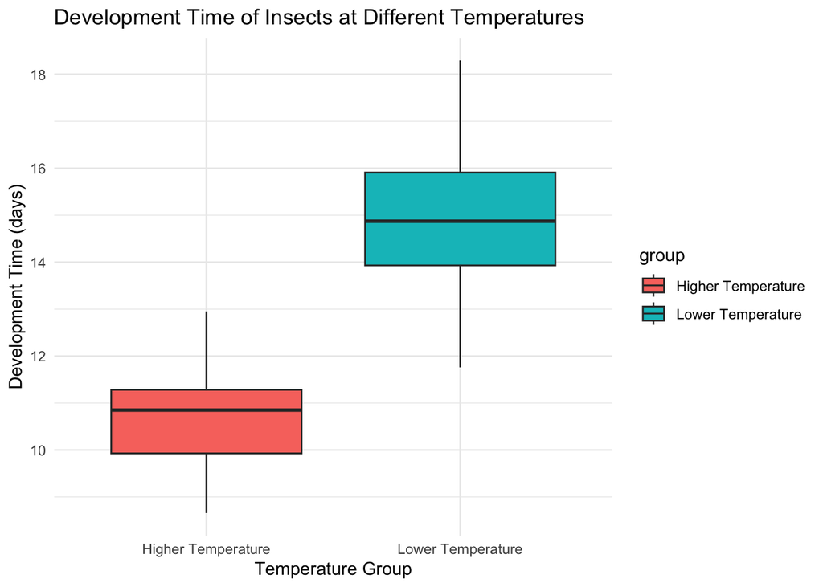

```r
# Create a box plot
boxplot <- ggplot(insect_data, aes(x = group, y = development_time, fill = group)) +
  geom_boxplot() +
  labs(title = "Development Time of Insects at Different Temperatures",
       x = "Temperature Group",
       y = "Development Time (days)") +
  theme_minimal()

# Display the box plot
print(boxplot)
```

Try running your analysis multiple times to get a feeling for how variable the results are with the same parameters, but different sets of random numbers.

```r
# Different run p-value and F value changes by rerunning the same codes:
# run #1
# pval = <2e-16 ***
# Fval= 190
# # run #2
# pval = <2e-16 ***
# Fval = 319

##### or
results <- list()
# Set the number of iterations
num_iterations <- 6

# Initialize a vector to store the ANOVA p-values
p_values <- numeric(num_iterations)

for (i in 1:num_iterations) {
  # Generate a new random dataset
  set.seed(i) # Set a different seed for each iteration
  hightemp <- data.frame(
    development_time = rnorm(30, mean = 10, sd = sqrt(1.5))
  )
  lowtemp <- data.frame(
    development_time = rnorm(30, mean = 15, sd = sqrt(2.0))
  )
  hightemp$group <- "Higher Temperature"
  lowtemp$group <- "Lower Temperature"
  insect_data <- rbind(hightemp, lowtemp)

  #  ANOVA
  anova <- aov(development_time ~ group, data = insect_data)
  p_values[i] <- summary(anova)[[1]]$`Pr(>F)`[1]

    # Store the results
    results[[i]] <- list(
      summary = summary(anova),
      data = insect_data)
  }

  # Print the p-values from each iteration
  print(p_values)
```

```
## [1] 9.138965e-25 4.716218e-17 5.132635e-24 1.012101e-20 1.859572e-21
## [6] 4.801209e-19
```

```r
  # Print the summaries of the models for each iteration
   for (i in 1:6) {
     cat("Iteration", i, ":\n")
    print(results[[i]]$summary)
}
```

```
## Iteration 1 :
##             Df Sum Sq Mean Sq F value Pr(>F)
## group        1  388.1   388.1   304.9 <2e-16 ***
## Residuals   58   73.8     1.3
## ---
## Signif. codes:  0 '***' 0.001 '**' 0.01 '*' 0.05 '.' 0.1 ' ' 1
## Iteration 2 :
##             Df Sum Sq Mean Sq F value Pr(>F)
## group        1  327.2   327.2   139.3 <2e-16 ***
## Residuals   58  136.3     2.3
## ---
## Signif. codes:  0 '***' 0.001 '**' 0.01 '*' 0.05 '.' 0.1 ' ' 1
## Iteration 3 :
##             Df Sum Sq Mean Sq F value Pr(>F)
## group        1  425.4   425.4     284 <2e-16 ***
## Residuals   58   86.9     1.5
## ---
## Signif. codes:  0 '***' 0.001 '**' 0.01 '*' 0.05 '.' 0.1 ' ' 1
## Iteration 4 :
##             Df Sum Sq Mean Sq F value Pr(>F)
## group        1 284.06  284.06   205.5 <2e-16 ***
## Residuals   58  80.16    1.38
## ---
## Signif. codes:  0 '***' 0.001 '**' 0.01 '*' 0.05 '.' 0.1 ' ' 1
## Iteration 5 :
##             Df Sum Sq Mean Sq F value Pr(>F)
## group        1  407.3   407.3   221.3 <2e-16 ***
## Residuals   58  106.7     1.8
## ---
## Signif. codes:  0 '***' 0.001 '**' 0.01 '*' 0.05 '.' 0.1 ' ' 1
## Iteration 6 :
##             Df Sum Sq Mean Sq F value Pr(>F)
## group        1  314.6  314.55   172.9 <2e-16 ***
## Residuals   58  105.5    1.82
## ---
## Signif. codes:  0 '***' 0.001 '**' 0.01 '*' 0.05 '.' 0.1 ' ' 1
```